# Неоднородность влияния бюджетной политики на регионы России

Илья Гуленков

2025-02-18

Abstract

В работе рассматривается влияние расходов региональных бюджетов на экономическую активность в российских регионах. На ежемесячных данных за период с 2009 по 2024 год для 79 регионов оценивается региональный фискальный мультипликатор - процентное изменение индекса деловой активности в ответ на шок бюджетных расходов, эквивалентный 1% подушевого ВРП региона. Медианная величина регионального мультипликатора достигает пика через 2 месяца после шока и составляет 1,09%. Более сильный отклик наблюдается в регионах с более высоким подушевым ВВП, высоким уровнем неравенства по доходам и преобладанием занятости на крупных предприятиях. Региональные бюджетные шоки также отражаются на экономике регионов-соседей значимыми спилловер-эффектами, величина которых зависит от размера экономики региона и его внешнеторговых связей. Результаты исследования подтверждают наличие макроэкономических последствий гетерогенности домохозяйств, фирм и регионов, а также демонстрируют, что активная бюджетная политика экономически более развитых регионов может выступать фактором усиления межрегионального неравенства.

Ключевые слова: фискальный мультипликатор, региональный бюджет, бюджетная политика, региональная неоднородность, пространственные эффекты

JEL: E62, H72, C33

# Введение

Фискальная политика традиционно используется не только в качестве контрциклического инструмента на уровне всей страны, но и для сглаживания региональных диспропорций. Для повышения эффективности перераспределения ресурсов с помощью бюджетного процесса необходимо детальное понимание механизма фискальной трансмиссии и величины возникающих эффектов как во времени, так и в пространстве. В настоящий момент в академической литературе консенсус по этому вопросу отсутствует.

Влияние фискальной политики на экономическую активность чаще всего описывается с помощью мультипликатора - величины, определяющей изменение совокупного выпуска в ответ на единичное изменение государственных расходов. В обзоре эмпирических работ, посвящённых США, Ramey (2011) заключает, что величина мультипликатора на национальном уровне лежит между 0.8 и 1.5. При этом отмечается широкий разброс оценок в зависимости от периода, инструмента политики и персистентности шока. Более поздние эмпирические работы демонстрируют, что мультипликатор может зависеть от фазы делового цикла и источника шоков, с которыми сталкивается экономика (Auerbach & Gorodnichenko, 2011; Ghassibe & Zanetti, 2022), в то время как современные структурные модели выделяют предпосылки о распределении доходов между агентами как ключевой фактор, влияющий на размер мультипликатора (Auclert и др., 2023; Broer и др., 2023; Cantore & Freund, 2021). Существующие оценки мультипликатора бюджетных расходов для России разнятся от 0.1 до 0.9, однако отмечается их неоднородность в зависимости от типа бюджетных расходов и периода оценки (Зяблицкий, 2020).

Выраженная дифференциация регионов по уровню экономического развития является предпосылкой для существования различий в эффективности бюджетной политики между регионами России. До недавнего времени доступность и качество данных позволяли оценивать фискальные мультипликаторы только на национальном уровне. Распространение дезагрегированных данных об экономической активности на субнациональном уровне сделало возможным оценку так называемых *локальных мультипликаторов*. Полученные с использованием гранулярных данных на уровне регионов и муниципалитетов и нестандартных схем идентификации, локальные мультипликаторы характеризуют разницу в динамике выпуска между регионами, возникающую из-за увеличения государственных расходов в одном регионе по сравнению с другим (Chodorow-Reich, 2019; Nakamura & Steinsson, 2014). Применение моделей, учитывающих кросс-секциональную вариацию, улучшает статистические свойства оценок, а также позволяет проконтролировать влияние факторов, действующих на все регионы одновременно. К ним относятся общие для всей экономики шоки или макроэкономическая политика на национальном уровне.

Обширная литература о локальных мультипликаторах свидетельствует, помимо прочего, что региональные бюджетные шоки отражаются на экономике регионов-соседей значимыми спилловер-эффектами. Auerbach и др. (2020) отмечают, что положительные эффекты перелива распространяются как через отрасли, напрямую связанные с бюджетополучателем цепочками поставок, так и через эффекты общего равновесия кейнсианского типа. Таким образом, оценка региональных мультипликаторов в отрыве от пространственных эффектов приводит к систематическому занижению их величины. Существование выраженных, но неоднородных спилловер-эффектов между регионами России также хорошо документировано в литературе (Демидова и др., 2021; Демидова & Иванов, 2016).

Настоящее исследование призвано оценить неоднородность эффектов фискальной политики на уровне регионов России. В нём впервые для анализа воздействия мер фискальной политики в российской экономике использована модель глобальной векторной авторегрессии (GVAR), которая позволяет учитывать возникающие спилловер-эффекты благодаря наличию межрегиональных взаимосвязей. Модель оценивается с помощью байесовских методов на месячных данных за период 2009 - 2024 гг. и включает данные о деловой активности, инфляции и исполнению бюджетов на уровне субъектов РФ, а также общероссийские переменные.

Решая поставленную задачу, настоящая работа вносит вклад в несколько направлений литературы.

Во-первых, автор получает оценки фискального мультипликатора для каждого региона России в отдельности, в то время как существующие работы оценивают его только на национальном уровне (Зяблицкий, 2020, прил. 1). Пиковый медианный отклик регионального выпуска на шок госрасходов, эквивалентный 1% ВРП, наблюдается через 2 месяца после шока и достигает 1.09%. Более сильный мультипликативный эффект наблюдается в более богатых регионах с высоким уровнем неравенства по доходам, а также более высокой долей занятости на крупных предприятиях.

Во-вторых, в работе оценивается величина спилловер-эффектов фискальной политики, т. е. воздействия фискального стимула в одном регионе на экономику его соседей. Показано, что величина этих эффектов зависит как от размера и структуры ВРП, так и от интенсивности внешней торговли, а также состояния регионального рынка труда. Эти результаты подтверждают и расширяют выводы предыдущих работ об ассиметричности пространственных эффектов между регионами России (Демидова, 2014).

Наконец, результаты исследования подтверждают наличие связи между эффективностью макроэкономической политики и внутри- и межрегиональным неравенством. В работе показано, что эффективность бюджетных расходов зависит от уровня экономического развития региона и дифференциации доходов домохозяйств. Выводы схожего характера были получены ранее при анализе трансмиссии монетарной политики в России (Зверева и др., 2024; Зверева & Скуратова, 2024; Напалков и др., 2021).

# Методология исследования

Для оценки фискального мультипликатора чаще всего используются структурные векторные авторегрессии или близкий к ним метод локальных проекций (Ramey, 2011). Такой подход не вызывает проблем при работе на национальном уровне, однако при применении на региональных данных может приводить к систематическому смещению оценок мультипликаторов из-за недоучёта возникающих спилловер-эффектов. Последние, в свою очередь, чаще всего оцениваются с помощью инструментария пространственной эконометрики, который налагает жёсткие предпосылки об однородности и симметрии спилловер-эффектов между всеми регионами. Кроме того, стандартные пространственные модели ограничивают анализ одной зависимой переменной.

В качестве эмпирической модели в данной работе сделан выбор в пользу глобальной векторной авторегрессии (GVAR), которая представляет собой обобщение моделей пространственной эконометрики для многомерного случая (Elhorst и др., 2021). Использование GVAR позволяет оценивать специфические для каждого региона коэффициенты при межвременных и пространственных связях, при этом обеспечивая согласованное моделирование региональных экономик как единой системы. Изначально GVAR разрабатывались для анализа на страновом уровне (*The GVAR Handbook*, 2013), однако эта методология успешно применяется в исследованиях на отраслевом (Hiebert & Vansteenkiste, 2010), региональном (Vansteenkiste, 2007), так и на межотраслевом уровне и городском уровне (Holly и др., 2011). В России GVAR применялись для оценки влияния внешнеэкономических шоков (Зубарев & Кириллова, 2023) и неоднородности реакции регионов на шоки ДКП (Напалков и др., 2021).

Поскольку публичные региональные данные о распределении расходов федерального бюджета по субъектам отсутствуют, в данной работе мы фокусируемся на последствиях шоков расходов региональных бюджетов и возникающих спилловер-эффектах. Под региональным бюджетным стимулом мы понимаем изменение расходов консолидированного бюджета субъекта, включающее расходы входящих в него муниципалитетов. На наш взгляд, для удовлетворительного моделирования пространственных и временных взаимосвязей между экономиками регионов России использование данных квартальной или, тем более, годовой частоты не является достаточным. В первую очередь это связано с тем, что меры фискальной политики обладают коротким внешним лагом трансмиссии и их влияние на региональную экономику, вероятнее всего, транслируется внутри года. Кроме того, использование данных меньшей частоты неминуемо приведет к резкому сокращению числа наблюдений и снизит точность оценок параметров. Исходя из этого в работе отдаётся предпочтение данным месячной частоты.

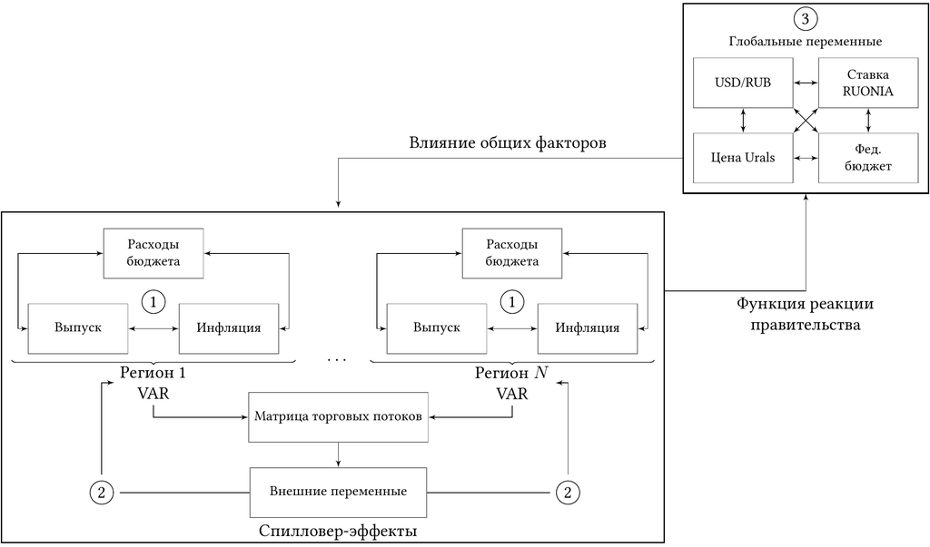

Figure 1: Структура GVAR-модели

Структура предлагаемой модели для российской экономики приведена на Рисунке 1. Переменные в ней делятся на три блока[^1]:

1. **Региональные переменные** включают логарифм индекса деловой активности ($100\log(y_{it})$), инфляцию в виде лог-разностей регионального ИПЦ ($100\log(P_{it})$), а также исполнение расходов коносолидированного бюджета субъекта на душу населения в реальном выражении ($\log(g_{it})$).
2. **Внешние переменные** представляют собой уникальную для каждого региона взвешенную комбинацию региональных переменных, относящихся к его регионам-соседям. В качестве взвешивающей матрицы мы применяем матрицу межрегиональных торговых потоков за 2016 год[^2] по данным Росстата.
3. **Глобальные переменные** включают общие для всех регионов России факторы: ставку денежного рынка RUONIA ($i_t$), а также логарифмы цены на нефть марки Urals ($\log(poil_t)$), валютного курса рубля к доллару ($\log(e_t)$), расходов ($\log(g_t)$) и доходов ($\log(tx_t)$) федерального бюджета.

Динамика переменных первого блока описывается VAR-моделью в каждом из $N$ регионов. В эту модель в качестве слабо экзогенных входят внешние переменные, являющиеся взвешеннным средним переменных других регионов. Предпосылка о слабой экзогенности позволяет оценивать региональные модели отдельно друг от друга и эквивалентна допущению о том, что каждый регион России представляет собой малую открытую экономику в монетарном союзе. Переменные блока 3 позволяют учесть влияние факторов, воздействующих на все регионы одновременно, таких как конъюнктура внешних рынков или макроэкономическая политика на федеральном уровне. При этом глобальные переменные могут реагировать на агрегированную региональную динамику. Например, уравнение ставки процента представляет собой вариант правила Тейлора, а доходы федерального бюджета зависят от деловой активности в регионах. Оценённые индивидуальные модели с помощью взвешивающей матрицы объединяются в систему, решение которой позволяет осуществлять прогнозирование или структурный анализ (Pesaran и др., 2004).

Выборка ограничена периодом с ноября 2009 г. по апрель 2024 г. из-за отсутствия более ранних помесячных данных о региональной деловой активности. Из-за неудовлетворительного качества и отсутствия некоторых исходных данных, из анализа исключаются Ненецкий, Ханты-Мансийский, Ямало-Ненецкий и Чукотский автономные округа, а также Республика Крым и Севастополь. В результате мы оцениваем 79 региональных моделей и 1 модель для глобальных переменных, которые впоследствии объединяются в единую GVAR-структуру для последующего анализа.

В общем виде оцениваемая для региона $i$ модель имеет следующий вид:

$$\begin{align}
\mathbf{x}_{it} = \mathbf{a}_{i0} + \mathbf{a}_{i1} t + \sum_{l=1}^{p_i} \mathbf{\Phi}_{il} \mathbf{x}_{i,t-l} + \mathbf{\Lambda}_{i0} \mathbf{x}^*_{i,t} + \sum_{l=1}^{q_i} \mathbf{\Lambda}_{il} \mathbf{x}^*_{i,t-l} + \mathbf{D}_{i0} \mathbf{\omega}_t + \sum_{l=1}^{s_i} \mathbf{D}_{il} \mathbf{\omega}_{t-l} + \varepsilon_{it},
\label{eq:gvarspec}
\end{align}$$

где $\mathbf{x}_{it}$ - вектор эндогенных переменных, $\mathbf{x}^*_{i,t}$ - вектор специфических для региона внешних переменных, $\mathbf{\omega}_t$ - вектор глобальных переменных. Величины $p_i$, $q_i$ и $s_i$ задают порядок лага модели. Матрицы $\mathbf{\Phi}_i$, $\mathbf{\Lambda}_i$ и $\mathbf{D}_i$ содержат оцениваемые коэффициенты, а вектор $\varepsilon_{it} \sim \text{i.i.d} (0, \Sigma_{ii})$ представляет собой случайные ошибки для региона $i$. В каждую модель включена константа и линейный тренд.

Внешние переменные рассчитываются как взвешенное среднее эндогенных переменных:

$$\begin{align}
\mathbf{x}^*_{it} = \sum_{j=1}^{N} \nu_{ij} \mathbf{x}_{jt},
\end{align}$$

где $\nu_{ij}$ - вес, характеризующий силу экономических связей между регионами. При этом $\nu_{ij} = 0$ и $\sum_{j=1}^N \nu_{ij} = 1$.

Для глобальных переменных специфицируется отдельная VAR-модель:

$$\begin{align}
\mathbf{\omega}_t = \sum_{l=1}^{p_\omega} \mathbf{\Phi}_{\omega l} \mathbf{\omega}_{t-l} + \sum_{l=1}^{q_\omega} \mathbf{\Lambda}_{\omega l} \mathbf{x}^*_{\omega,t-l} + \eta_{\omega t}
\end{align}$$

Ненулевые матрицы $\mathbf{\Lambda}_{\omega l}$ позволяют глобальным переменным зависеть от кросс-секциональных средних $\mathbf{x}^*_{\omega,t-l}$.

Для оценки параметров модели применяется байесовский подход. Обозначим за $\Psi_i$ вектор, содержащий все оцениваемые параметры для региона $i$, т. е. $(\mathbf{a}_{i0}, \mathbf{a}_{i1}, \mathbf{\Phi}_{i0}, \dots, \mathbf{\Lambda}_{i0}, \dots, \mathbf{D}_{i0})^T$. Коэффициенты региональных моделей имеют априорное нормальное распределение:

$$\begin{align}
\Psi_i \sim \mathcal{N}(\underline{\Psi}_i,\underline{V}_i)
\end{align}$$

Априорное среднее $\underline{\Psi}_i$ для всех коэффициентов установлено равным нулю. Априорная дисперсия $\underline{V}_i$ специфицирована согласно варианту распределения Миннесоты, который предполагает, что объясняющая способность выше для 1) собственных лаговых значений по сравнению с лагами других переменных, и 2) более близких лагов по сравнению с дальними (подробнее см. Boeck и др., 2022).

Оценка параметров модели осуществляется с помощью пакета BGVAR (Boeck и др., 2022) в среде R при помощи метода Монте-Карло для марковских цепей (Markov Chain Monte Carlo, MCMC). Используются 16 000 итераций, первые 15 000 которых отбрасываются для минимизации влияния начальных значений на сходимость цепи. Поскольку выборка включает в себя качественно отличающиеся периоды (посткризисное восстановление 2009 - 2010 гг., спад 2015 - 2016 гг, а также внешние шоки 2022 г. и последовавшую структурную перестройку), мы оцениваем модель со стохастической волатильностью остатков, которая может меняться во времени.

Порядок лага для всех видов переменных задаётся равным 1. F-тест на автокорреляцию в остатках модели демонстрирует, что для половины переменных гипотеза об отсутствии автокорреляции не отвергается на 1% уровне значимости[^3].

Перед работой с моделью проводится диагностика сходимости марковских цепей к целевому распределению. Тест Гевеке, сравнивающий среднее значение параметра в начале и конце цепи, демонстрирует, что на 95%-м уровне значимости можно констатировать сходимость для 87.1% параметров.

Table 1: Средние коэффициенты корреляции между переменными и остатками модели в регионах России

| Коэффициент корреляции | Госрасходы Данные | Госрасходы Остатки модели | Выпуск Данные | Выпуск Остатки модели | Инфляция Данные | Инфляция Остатки модели |
| --- | --- | --- | --- | --- | --- | --- |
| <0.1 | 1 (1.25%) | 32 (40%) | 4 (5.06%) | 68 (86.08%) | 0 (0%) | 0 (0%) |
| 0.1-0.2 | 2 (2.5%) | 48 (60%) | 6 (7.59%) | 11 (13.92%) | 0 (0%) | 1 (1.27%) |
| 0.2-0.5 | 9 (11.25%) | 0 (0%) | 34 (43.04%) | 0 (0%) | 0 (0%) | 6 (7.59%) |
| >0.5 | 68 (85%) | 0 (0%) | 35 (44.3%) | 0 (0%) | 79 (100%) | 72 (91.14%) |

Примечание: в таблице приведено число и доля регионов, для которых средний коэффициент корреляции между региональными переменными (или остатками уравнений модели) лежит в указанном диапазоне

Одно из ключевых допущений GVAR-анализа предполагает, что большая часть корреляции между региональными переменными в пространстве объясняется динамикой внешних переменных. Иными словами, после включения слабо-экзогенных внешних переменных остатки модели для различных регионов должны быть слабо коррелированы между собой. Выполнение этой предпосылки проверяется в Таблице 1. Для каждой переменной в выбранном регионе рассчитывается коэффициент её корреляции с аналогичной переменной в других регионах. Затем этот коэффициент корреляции усредняется, после чего подсчитывается число регионов, для которых этот коэффициент лежит в заданном диапазоне. Аналогичная процедура проводится для остатков региональных моделей.

# Оценка фискальных мультипликаторов в регионах России

Как и в стандартных VAR, остатки GVAR-модели в приведённой форме не могут быть интерпретированы как структурные экономические шоки, так как они коррелируют друг с другом. Структурный анализ требует решения проблемы идентификации. Эта процедура предполагает использование экономической теории или иной внешней по отношению к модели информации, которая накладывает ограничения на отдельные элементы ковариационной матрицы и позволяет привести её к ортогональному виду. Применительно к шокам бюджетных расходов наиболее часто применяются рекурсивная (Fatás & Mihov, 2001) или нарративная (Ramey & Zubairy, 2018) схемы идентификации, а также знаковые ограничения (Mountford & Uhlig, 2009).

Используемая в настоящем исследовании модель оценивается на данных о кассовом исполнении региональных бюджетов, которые фиксируют бюджетные расходы в момент их перечисления бюджетополучателям. Поскольку фискальная политика обладает существенным внутренним лагом, работа с данными месячной частоты позволяет применить для идентификации шоков государственных расходов рекурсивную схему. В частности, предполагается, что в рамках одного месяца региональные шоки спроса и предложения не оказывают влияния на величину государственных расходов[^4]. Отметим, что идентификация в GVAR-моделях является локальной: шок госрасходов ортогонален другим региональным шокам, но может коррелировать с шоками расходов в других регионах. На практике эта корреляция оказывается положительной, но пренебрежительной малой по своему размеру (см. Таблицу 1).

Поскольку регоны России отличаются между собой как по объёму бюджетных расходов, так и по численности населения, в качестве меры реакции регионального выпуска на шок госрасходов используется модифицированное определение мультипликатора, отражающего процентное изменение выпуска в ответ на рост госрасходов, эквивалентный 1% подушевого ВВП региона:

$$\begin{align}
mult^y_{ijh} = IRF^{y,g}_{ijh} \times \frac{1}{\bar{g}_j} \times \overline{GRP}_j \times 0.01
\end{align}$$

где $IRF^{y,g}_{ijh}$ - функция импульсного отклика выпуска в регионе $i$ на шок госрасходов в регионе $j$ на горизонте $h$, $\bar{g}_j$ - средний уровень расходов бюджета на душу населения в регионе $j$, а $\overline{GRP}_j$ - средний уровень ВРП на душу населения в реальном выражении.

Table 2: Оценка мультипликатора государственных расходов в российских регионах

| Статистика | Горизонт (месяцев) 0 | Горизонт (месяцев) 1 | Горизонт (месяцев) 3 | Горизонт (месяцев) 6 | Горизонт (месяцев) 12 | Горизонт (месяцев) 24 |
| --- | --- | --- | --- | --- | --- | --- |
| Минимум | -1.97 | -2.03 | -1.75 | -1.61 | -0.79 | -0.23 |
| 15-й перцентиль | -0.35 | -0.20 | -0.18 | -0.02 | 0.00 | 0.00 |
| Медиана | 0.73 | 1.02 | 0.92 | 0.43 | 0.11 | 0.02 |
| 85-й перцентиль | 1.86 | 2.92 | 3.37 | 2.62 | 1.35 | 0.44 |
| Максимум | 3.62 | 7.16 | 8.15 | 7.81 | 5.26 | 2.14 |
| Среднее1 | 0.70 | 1.61 | 1.86 | 1.46 | 0.81 | 0.30 |
| Доля значимых2 | 0.37 | 0.48 | 0.47 | 0.47 | 0.54 | 0.68 |

Примечание: оценки получены с помощью GVAR-модели на выборке 2009-2024 гг. Под мультипликатором понимается процентное изменение индекса деловой активности в ответ на увеличение госрасходов, эквивалентное 1% ВРП. Описательные статистики рассчитаны по 79 регионам.  
1При расчёте среднего в качестве весов используется региональный подушевой ВРП  
2Для проверки значимости используются 68%-е достоверные интервалы

В таблице 2 приведены ключевые описательные статистики, характеризующие распределение полученных региональных мультипликаторов. Результаты расчётов для каждого региона в отдельности доступны в онлайн-приложении.

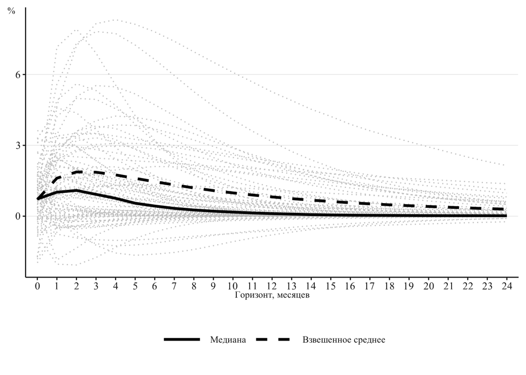

Figure 2: Динамика мультипликатора государственных расходов в российских регионах

Полученные результаты в целом согласуются по величине с существующими оценками, хотя и оказываются несколько выше известных результатов для России (Зяблицкий, 2020). Это может быть связано как минимум с двумя факторами. Во-первых, существующие исследования фокусируются на расходах федерального бюджета[^6], в котором выше доля “непродуктивных” расходов (общегосударственные вопросы, национальная оборона и безопасность), обладающих меньшим мультипликативным эффектом (Кудрин & Кнобель, 2017). Кроме того, в качестве индикатора деловой активности в данном исследовании используется композитный индекс динамики отраслей, доля которых в ВДС регионов колеблется от 20-30% (Республика Калмыкия, Камчатский край, Республика Ингушетия) до 80% и выше (Тюменская, Сахалинская, Кемеровская область, Красноярский Край). В результате мультипликаторы, оценённые с опорой на весь ВВП, могут отличаться от оценок по подмножеству его отраслей.

Помимо оценок прямых эффектов бюджетных расходов на экономику регионов, мы также рассчитываем среднюю величину двух спилловер-эффектов: spill-out и spill-in. Эффект spill-out отражает, насколько сильно другие регионы реагируют на шоки бюджетных расходов в заданном регионе $j$:

$$\begin{align}
SO_j = \sum_{i\neq j} \omega_{i} mult^y_{ijh},
\end{align}$$

где $\omega_i=\frac{GRP_i}{\sum_k GRP_k}$. Эффект spill-in, напротив, определяется как чувствительность заданного региона $i$ к государственным расходам в других регионах:

$$\begin{align}
SI_i = \sum_{j\neq i} \omega_j mult^y_{ijh},
\end{align}$$

где $\omega_j = \frac{GRP_j}{\sum_k GRP_k}$.

Table 3: Оценка величины спилловер-эффектов в российских регионах

| Статистика | Горизонт (месяцев) Эффект spill-out1 0 | Горизонт (месяцев) Эффект spill-out1 1 | Горизонт (месяцев) Эффект spill-out1 3 | Горизонт (месяцев) Эффект spill-out1 6 | Горизонт (месяцев) Эффект spill-out1 12 | Горизонт (месяцев) Эффект spill-out1 24 | Горизонт (месяцев) Эффект spill-in2 0 | Горизонт (месяцев) Эффект spill-in2 1 | Горизонт (месяцев) Эффект spill-in2 3 | Горизонт (месяцев) Эффект spill-in2 6 | Горизонт (месяцев) Эффект spill-in2 12 | Горизонт (месяцев) Эффект spill-in2 24 |
| --- | --- | --- | --- | --- | --- | --- | --- | --- | --- | --- | --- | --- |
| Минимум | 0.00 | 0.00 | 0.00 | 0.00 | -0.00 | -0.00 | -0.16 | -0.14 | -0.18 | -0.15 | -0.05 | -0.05 |
| 15-й перцентиль | 0.00 | 0.00 | 0.00 | 0.00 | 0.00 | 0.00 | 0.00 | 0.01 | 0.02 | 0.04 | 0.03 | 0.02 |
| Медиана | 0.01 | 0.01 | 0.02 | 0.02 | 0.01 | 0.01 | 0.03 | 0.05 | 0.09 | 0.11 | 0.10 | 0.06 |
| 85-й перцентиль | 0.04 | 0.07 | 0.10 | 0.11 | 0.10 | 0.06 | 0.09 | 0.14 | 0.17 | 0.16 | 0.14 | 0.09 |
| Максимум | 0.20 | 0.36 | 0.57 | 0.68 | 0.66 | 0.46 | 0.29 | 0.40 | 0.40 | 0.29 | 0.19 | 0.14 |
| Среднее | 0.02 | 0.04 | 0.05 | 0.06 | 0.05 | 0.03 | 0.05 | 0.08 | 0.10 | 0.10 | 0.09 | 0.06 |
| Доля значимых3 | 0.53 | 0.64 | 0.72 | 0.75 | 0.75 | 0.65 | 0.53 | 0.64 | 0.72 | 0.75 | 0.75 | 0.65 |

Примечание: оценки получены с помощью GVAR-модели на выборке 2009-2024 гг. Во всех случаях размер шока нормализован к 1% ВРП региона-источника шока. Описательные статистики рассчитаны по 79 регионам.  
1Spill-out эффект представляет собой усреднённую реакцию выпуска всех других регионов на шок госрасходов в заданном регионе  
2Spill-in эффект отражает чувствительность выпуска заданного региона к шокам госрасходов во всех других регионах  
3Для проверки значимости используются 68%-е достоверные интервалы

Полные результаты расчётов по каждому региону доступны в онлайн-приложении. Спилловер-эффекты оказываются достаточно выражены (см. Таблицу 3). На горизонте 1 года 1%-й рост подушевых госрасходов в одном регионе приводит к росту деловой активности других регионов в среднем на 0.05%. Средний регион России реагирует на изменение расходов бюджета в других регионах на 0.09%. В обоих случаях около 75% откликов значимо отличаются от нуля.

# Факторы гетерогенности

Полученные результаты демонстрируют, что влияние бюджетных расходов на региональную экономику, а также сила возникающих спилловер-эффектов имеют выраженную региональную неоднородность. На карте (см. Рисунок 3) приведено пространственное распределение отклика выпуска на горизонте 2 месяцев, что приблизительно отражает пиковое воздействие шока бюджетных расходов на экономику.

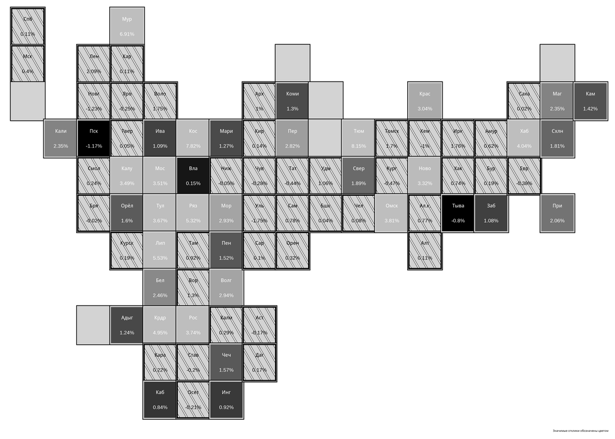

Figure 3: Оценка мультипликатора госрасходов на горизонте 2 месяцев

Из-за того, что импульсные отклики имеют достаточно широкие достоверные интервалы, с формальной точки зрения гипотеза о значимости различий между регионами не была бы отвергнута для большинства попарных сравнений. Это вызвано, в первую очередь, достаточно коротким интервалом оценки модели, её высокой параметризацией и, в некоторых случаях, невысоким качеством исходных статистических данных. На аналогичный результат указывают Напалков и др. (2021), отмечая, что анализ возможных источников наблюдаемой гетерогенности в любом случае представляет интерес. Руководствуясь этой логикой, в этом разделе мы проверяем связь отклика региональных переменных с характеристиками этих регионов.

Теоретическая литература предсказывает, что ключевой фактор, определяющий величину возникающих эффектов - география торговых и производственных связей между регионами. Чем интенсивнее регион торгует с соседями, тем ниже окажется фискальный мультипликатор и сильнее величина спилловер-эффектов (Dupor и др., 2023). Формализуя эту идею в пространственной модели общего равновесия, Норрис предсказывает, что наибольшим эффектом на ВВП страны будут обладать расходы, концентрирующиеся в регионах с дефицитом торгового баланса по отношению к другим регионам (Norris, 2019). Бернандини и соавторы показывают эмпирически, что перераспределение фиксированного объема госрасходов в пространстве в пользу таких регионов имеет стимулирующий эффект (Bernardini и др., 2020).

DSGE-модели открытой экономики, в которых два региона составляют федерацию, демонстрируют, что величина спилловер-эффектов также может зависеть от способа финансирования расходов: дефицит местного бюджета или трансфер из федерального бюджета, финансируемый пропорционально всеми членами союза (Chodorow-Reich, 2019; Dupor и др., 2023; Nakamura & Steinsson, 2014). Среди других факторов, влияющих на величину фискального мультипликатора, выделяют композицию госрасходов и их распределение между трудо- и капиталоёмкими отраслями (Juarros и др., 2023), уровень внутри- и межрегионального неравенства и остроты ограничений на заимствование (Bernardini и др., 2020; Debuque-Gonzales, 2021), а также степень жёсткости цен и заработных плат (Carvalho и др., 2023).

Исходя из этих соображений и доступности данных на региональном уровне, в качестве потенциальных факторов гетерогенности выделяются[^7]:

1. Размер и структура экономики: реальный ВРП на душу населения, доля добывающей, обрабатывающей промышленности и строительства в ВРП
2. Распределение доходов: децильный коэффициент и доля населения с доходами ниже границы бедности
3. Региональный рынок труда: уровень безработицы, число безработных на одну вакансию, доля занятых в организациях с негосударственной формой собственности, доля занятых на малых и средних предприятиях[^8]
4. Внешнеторговые связи: доля импорта из-за рубежа в ВРП, отношение отгрузки продукции из других регионов России и в другие регионы России к отгрузке в регион[^9]
5. Региональный бюджет: уровень регионального долга к ВРП (за исключением бюджетных кредитов), доля расходов регионального бюджета на нацоборону, безопасность, нацэкономику и социальную сферу

В качестве зависимой переменной используется отклик выпуска, уровня цен, а также средняя величина spill-out и spill-in эффекта для региона на горизонте 3 месяцев. При оценке модели наблюдения взвешиваются по среднему подушевому ВРП регионов.

Table 4: Факторы гетерогенности отклика выпуска на шок госрасходов

|  | ВРП | Неравенство | Рынок труда | Внешняя торговля | Бюджет |
| --- | --- | --- | --- | --- | --- |
| Константа | -22.44 *** | -2.85 | 4.06 | 2.11 *** | -2.43 |
| Логарифм ВРП на душу | 1.67 *** |  |  |  |  |
| Доля добычи в ВРП | 0.01 |  |  |  |  |
| Доля обработки в ВРП | 0.18 |  |  |  |  |
| Доля строительства в ВРП | 0.07 ** |  |  |  |  |
| Децильный коэффициент |  | 0.89 ** |  |  |  |
| Уровень бедности |  | -0.05 |  |  |  |
| Доля занятости в частном секторе |  |  | 0.06 |  |  |
| Доля занятости на МСП |  |  | -0.14 *** |  |  |
| Жёсткость рынка труда |  |  | 0.01 |  |  |
| Безработица |  |  | -0.21 |  |  |
| Импорт/ВРП |  |  |  | -0.00 |  |
| Отгрузка товаров из других регионов |  |  |  | -0.11 |  |
| Отгрузка товаров в другие регионы |  |  |  | -0.00 |  |
| Расходы на нацоборону |  |  |  |  | -1.31 |
| Расходы на нацбезопасность |  |  |  |  | 0.94 |
| Социальные расходы |  |  |  |  | 0.08 |
| Расходы на нацэкономику |  |  |  |  | 0.10 * |
| Госдолг к ВРП |  |  |  |  | -0.21 |
| N | 79 | 79 | 79 | 79 | 79 |
| R^2 | 0.22 | 0.13 | 0.25 | 0.03 | 0.10 |
| R^2 adj. | 0.18 | 0.11 | 0.21 | -0.01 | 0.04 |
| F statistic | 5.30 | 5.59 | 6.21 | 0.75 | 1.57 |
| P value | 0.00 | 0.01 | 0.00 | 0.52 | 0.18 |
| *** p < 0.01; ** p < 0.05; * p < 0.1. |  |  |  |  |  |

Из-за ограниченного числа наблюдений анализ проводится по отдельным блокам переменных. Результаты приведены в Таблице 4.

Мультипликатор выпуска оказывается выше в более богатых регионах в расчёте на душу населения. Кроме того, его величина положительно связана с долей строительной отрасли в ВРП. Это может объясняться дополнительным спросом, который предъявляет строительная отрасль на продукцию других отраслей, что увеличивает мультипликативный эффект. Мультипликатор оказывается тем выше, чем выше уровень внутрирегионального неравенства. Более выраженная дифференциация жителей региона по доходам может приводить к существенным различиям в склонности к потреблению, что увеличивает силу индуцированных эффектов фискальной политики. Аналогичный эффект может ожидаться и по отношению к фирмам: малые предприятия гораздо чаще сталкиваются с ограничениями ликвидности, и должны активнее реагировать на положительные фискальные шоки из-за балансовых эффектов Juarros (2022). Результаты анализа, однако, свидетельствуют об обратном: в регионах с высокой долей занятости на малых и средних предприятиях мультипликатор оказывается ниже. Это свидетельствует о том, что “кредитный канал” фискальной политики влияет скорее на крупные предприятия, в то время как острота кредитных ограничений для МСП не зависит от мер фискальной политики. Наконец, регионы с большей долей расходов на нацэкономику в бюджете имеют более высокий мультипликатор, что подтверждает выводы предыдущих исследований о более высокой эффективности производительных бюджетных расходов.

# Дискуссия

**В ДИСКУССИЮ** Так, производительные расходы (инфраструктура и здравоохранение) обладают большим эффектом на экономику, чем непроизводительные (национальная оборона и безопасность) (Кудрин & Кнобель, 2017), а мультипликатор расходов по абсолютной величине ниже, чем мультипликатор бюджетных доходов (Власов & Дерюгина, 2018).

**В ДИСКУССИЮ**В результате реакция регионов на шоки стабилизационных политик может существенно отличаться. До настоящего момента в литературе уделялось внимание только неоднородности реакции регионов России на единую денежно-кредитную политику (Зверева и др., 2024; Зверева & Скуратова, 2024; Напалков и др., 2021), в то время как дифференциация реакции регионов на меры фискальной политики остаётся неизученной. Настоящее исследование призвано восполнить этот пробел и оценить, как отличается реакция различных регионов России на шоки расходов бюджета, определить причины этих различий и силу пространственных связей между регионами.

**В ДИСКУССИЮ**Существующие исследования демонстрируют, что бюджетно-налоговые меры вызывают значимые и разнонаправленные спилловер-эффекты и обладают различной эффективностью в зависимости от композиции расходов бюджета, способа их финансирования, уровня неравенства, остроты кредитных ограничений и паттернов межрегиональной торговли (Bernardini и др., 2020; Chodorow-Reich, 2019). Полноценная репликация этих подходов на российских данных не представляется возможной из-за отсутствия детализированных данных об экономической активности и госрасходах на локальном уровне.

**В ДИСКУССИЮ**Вместе с тем, сильная пространственная дифференция экономического развития России может приводить к неоднородному воздействию макроэкономической политики на экономику регионов. Так, исследования последних лет показывают, что реакция регионов России на изменение ключевой ставки зависит от степени неравенства, отраслевой структуры экономики и уровня конкуренции (Зверева и др., 2024; Зверева & Скуратова, 2024). Аналогичных исследований о влиянии фискальных мер, насколько известно автору, не проводилось.

# Заключение

Проведённое исследование демонстрирует, что фискальная политика оказывает неоднородное влияние на экономику российских регионов. Использование GVAR-модели позволило оценить не только локальные фискальные мультипликаторы, но и межрегиональные спилловер-эффекты. Результаты подтверждают, что бюджетные стимулы могут как напрямую повышать выпуск в целевом регионе, так и оказывать воздействие на соседние регионы. Величина этих эффектов определяется не только размерами экономики, но и отраслевой структурой выпуска, уровнем неравенства, а также параметрами рынка труда и внешнеторговыми связями.

Выявлено, что фискальная политика оказывается более эффективной в регионах с высоким уровнем ВРП на душу населения. В таких регионах бюджетные стимулы приводят к более выраженному росту выпуска, что может быть связано с более глубоким внутренним рынком, преобладанием сферы услуг и более высокой долей крупных предприятий, способных быстрее реагировать на изменения в спросе. Вместе с тем, экономически развитые регионы обладают устойчивой большой налоговой базой, что расширяет доступное им фискальное пространство и позволяет проводить более активную фискальную политику. Полученные результаты свидетельствуют о том, что это может усиливать межрегиональное неравенство и требует проведения активной перераспределительной политики на федеральном уровне.

Значительная вариативность реакции выпуска на фискальные шоки, а также их зависимость от состояния локального рынка труда, может указывать также на отличия в степени номинальных жёсткостей между регионами России.

Таким образом, результаты исследования подтверждают сложную природу фискальной трансмиссии в экономике с большой региональной дифференциацией. Полученные результаты обосновывают необходимость дальнейшего изучения влияния фискальной политики с использованием гранулярных данных на уровне регионов, фирм или отдельных домохозяйств.

# Список использованной литературы

Auclert, A., Bardóczy, B., & Rognlie, M. (2023). MPCs, MPEs, and Multipliers: A Trilemma for New Keynesian Models. *The Review of Economics and Statistics*, *105*(3), 700–712. https://doi.org/10.1162/rest_a_01072

Auerbach, A. J., & Gorodnichenko, Y. (2011). Fiscal Multipliers in Recession and Expansion (Preprint). *NBER Working Paper Series*, *17447*. https://doi.org/10.3386/w17447

Auerbach, A. J., Gorodnichenko, Y., & Murphy, D. (2020). Local Fiscal Multipliers and Fiscal Spillovers in the USA. *IMF Economic Review*, *68*(1), 195–229. https://doi.org/10.1057/s41308-019-00102-3

Bernardini, M., De Schryder, S., & Peersman, G. (2020). Heterogeneous Government Spending Multipliers in the Era Surrounding the Great Recession. *The Review of Economics and Statistics*, *102*(2), 304–322. https://doi.org/10.1162/rest_a_00830

Boeck, M., Feldkircher, M., & Huber, F. (2022). BGVAR: Bayesian Global Vector Autoregressions with Shrinkage Priors in R. *Journal of Statistical Software*, *104*, 1–28. https://doi.org/10.18637/jss.v104.i09

Broer, T., Krusell, P., & Öberg, E. (2023). Fiscal Multipliers: A Heterogeneous‐agent Perspective. *Quantitative Economics*, *14*(3), 799–816. https://doi.org/10.3982/QE1901

Cantore, C., & Freund, L. B. (2021). Workers, Capitalists, and the Government: Fiscal Policy and Income (Re)Distribution. *Journal of Monetary Economics*, *119*, 58–74. https://doi.org/10.1016/j.jmoneco.2021.01.004

Carvalho, B. P., Franco, F., & Peralta, S. (2023). *Local Finance and Job Creation: Examining Local Fiscal Multipliers on Private Employment*. https://drive.google.com/file/d/1rgFioOlXpZtZd24TVqBFe5dxZ62tGJv9/view

Chodorow-Reich, G. (2019). Geographic Cross-Sectional Fiscal Spending Multipliers: What Have We Learned? *American Economic Journal: Economic Policy*, *11*(2), 1–34. https://doi.org/10.1257/pol.20160465

Chudik, A., & Pesaran, M. H. (2016). Theory and Practice of Gvar Modelling. *Journal of Economic Surveys*, *30*(1), 165–197. https://doi.org/10.1111/joes.12095

Debuque-Gonzales, M. (2021). Local Fiscal Multipliers and Spillover Effects: Evidence from Philippine Regions. *Economic Systems*, *45*(2), 100764. https://doi.org/10.1016/j.ecosys.2020.100764

Dupor, B., Karabarbounis, M., Kudlyak, M., & Saif Mehkari, M. (2023). Regional Consumption Responses and the Aggregate Fiscal Multiplier. *The Review of Economic Studies*, *90*(6), 2982–3021. https://doi.org/10.1093/restud/rdad007

Elhorst, J. P., Gross, M., & Tereanu, E. (2021). Cross-Sectional Dependence and Spillovers in Space and Time: Where Spatial Econometrics and Global Var Models Meet. *Journal of Economic Surveys*, *35*(1), 192–226. https://doi.org/10.1111/joes.12391

Espinoza, R., Gamboa-Arbelaez, J., & Sy, M. (2024). The Fiscal Multiplier of Public Investment: The Role of Corporate Balance Sheet. *The B.E. Journal of Macroeconomics*, *24*(1), 489–527. https://doi.org/10.1515/bejm-2023-0077

Fatás, A., & Mihov, I. (2001). The Effects of Fiscal Policy on Consumption and Employment: Theory and Evidence. *CEPR Discussion Papers*, *2760*. https://ideas.repec.org//p/cpr/ceprdp/2760.html

Ghassibe, M., & Zanetti, F. (2022). State Dependence of Fiscal Multipliers: The Source of Fluctuations Matters. *Journal of Monetary Economics*, *132*, 1–23. https://doi.org/10.1016/j.jmoneco.2022.09.003

Hiebert, P., & Vansteenkiste, I. (2010). International Trade, Technological Shocks and Spillovers in the Labour Market: A GVAR Analysis of the US Manufacturing Sector. *Applied Economics*, *42*(24), 3045–3066. https://doi.org/10.1080/00036840801964864

Holly, S., Hashem Pesaran, M., & Yamagata, T. (2011). The Spatial and Temporal Diffusion of House Prices in the UK. *Journal of Urban Economics*, *69*(1), 2–23. https://doi.org/10.1016/j.jue.2010.08.002

Juarros, P. (2022). Fiscal Stimulus, Credit Frictions and the Amplification Effects of Small Firms. *Unpublished*.

Juarros, P., Muratori, U., & Valderrama, D. (2023). Heterogeneous Spending, Heterogeneous Multipliers. *IMF Working Papers*, *2023*(052), 1. https://doi.org/10.5089/9798400233777.001

Mountford, A., & Uhlig, H. (2009). What Are the Effects of Fiscal Policy Shocks? *Journal of Applied Econometrics*, *24*(6), 960–992. https://doi.org/10.1002/jae.1079

Nakamura, E., & Steinsson, J. (2014). Fiscal Stimulus in a Monetary Union: Evidence from US Regions. *American Economic Review*, *104*(3), 753–792. https://doi.org/10.1257/aer.104.3.753

Norris, J. J. (2019). *Fiscal Multipliers in Integrated Local Labor Markets*.

Pesaran, M. H., Schuermann, T., & Weiner, S. M. (2004). Modeling Regional Interdependencies Using a Global Error-Correcting Macroeconometric Model. *Journal of Business & Economic Statistics*, *22*(2), 129–162. https://doi.org/10.1198/073500104000000019

Ramey, V. A. (2011). Can Government Purchases Stimulate the Economy? *Journal of Economic Literature*, *49*(3), 673–685. https://doi.org/10.1257/jel.49.3.673

Ramey, V. A., & Zubairy, S. (2018). Government Spending Multipliers in Good Times and in Bad: Evidence from US Historical Data. *Journal of Political Economy*, *126*(2), 850–901. https://doi.org/10.1086/696277

*The GVAR Handbook: Structure and Applications of a Macro Model of the Global Economy for Policy Analysis*. (2013). Oxford University Press. https://academic.oup.com/book/36247

Vansteenkiste, I. (2007). Regional Housing Market Spillovers in the US: Lessons from Regional Divergences in a Common Monetary Policy Setting. *SSRN Electronic Journal*. https://doi.org/10.2139/ssrn.954700

Власов, С. А., & Дерюгина, Е. Б. (2018). Фискальные мультипликаторы в России. *Журнал Новой Экономической Ассоциации*, *2*(38), 104–119. https://doi.org/10.31737/2221-2264-2018-38-2-5

Демидова, О. А. (2014). Пространственно – авторегрессионная модель для двух групп взаимосвязанных регионов (на примере восточной и западной части России). *Прикладная эконометрика*, *34*(2), 19–35. https://publications.hse.ru/articles/publications.hse.ru/articles/120990566

Демидова, О. А., & Иванов, Д. С. (2016). Модели экономического роста с неоднородными пространственными эффектами (на примере российских регионов). *Экономический журнал Высшей школы экономики*, *20*(1), 52–75. https://publications.hse.ru/articles/publications.hse.ru/articles/181143290

Демидова, О. А., Каяшева, Е. В., & Демьяненко, А. В. (2021). Государственные расходы на здравоохранение и экономический рост в России: региональный аспект. *Пространственная эконометрика*, *17*(1), 97–122. https://doi.org/10.14530/se.2021.1.097-122

Зверева, В. А., Демидова, О. А., А, К. Д., & Мясников, А. А. (2024). Влияние внутрирегионального неравенства по доходам на работу трансмиссионного механизма денежно-кредитной политики Банка России. *Деньги и кредит*, *83*(1), 3–31. https://publications.hse.ru/articles/publications.hse.ru/articles/909673909

Зверева, В. А., & Скуратова, А. В. (2024). Реакция Банковских Ставок На Изменение Ключевой Ставки Банка России в Условиях Региональной Неоднородности (Оценки На Панельных Данных). *Банк России, Серия докладов об экономических исследованиях*, *129*. https://www.cbr.ru/StaticHtml/File/161845/wp_129_2.pdf

Зубарев, А. В., & Кириллова, М. А. (2023). Построение модели GVAR для российской экономики. *Экономический журнал Высшей школы экономики*, *27*(1), 9–32. https://ej.hse.ru/2023-27-1/819336633.html

Зяблицкий, И. Е. (2020). Оценка фискальных мультипликаторов в российской экономике. *Экономический Журнал Высшей Школы Экономики*, *24*(2), 268–294. https://doi.org/10.17323/1813-8691-2020-24-2-268-294

Кудрин, А. Л., & Кнобель, А. Ю. (2017). Бюджетная политика как источник экономического роста. *Вопросы Экономики*, *10*, 5–26. https://doi.org/10.32609/0042-8736-2017-10-5-26

Напалков, В., Новак, А., & Шульгин, А. (2021). Различия в эффектах единой денежно-кредитной политики: случай регионов России. *Деньги и кредит*, *80*(1), 3–45. https://doi.org/10.31477/rjmf.202101.03

# Приложение 1. Факторы гетерогенности спилловер-эффектов

Table 5: Факторы гетерогенности spill-out эффектов

|  | ВРП | Неравенство | Рынок труда | Внешняя торговля | Бюджет |
| --- | --- | --- | --- | --- | --- |
| Константа | -1.07 *** | -0.15 *** | -0.08 | 0.03 *** | -0.04 |
| Логарифм ВРП на душу | 0.09 *** |  |  |  |  |
| Доля добычи в ВРП | -0.00 *** |  |  |  |  |
| Доля обработки в ВРП | 0.00 |  |  |  |  |
| Доля строительства в ВРП | -0.00 |  |  |  |  |
| Децильный коэффициент |  | 0.04 *** |  |  |  |
| Уровень бедности |  | -0.00 * |  |  |  |
| Доля занятости в частном секторе |  |  | 0.00 *** |  |  |
| Доля занятости на МСП |  |  | -0.00 * |  |  |
| Жёсткость рынка труда |  |  | 0.00 * |  |  |
| Безработица |  |  | -0.00 |  |  |
| Импорт/ВРП |  |  |  | 0.00 *** |  |
| Отгрузка товаров из других регионов |  |  |  | 0.00 |  |
| Отгрузка товаров в другие регионы |  |  |  | -0.01 ** |  |
| Расходы на нацоборону |  |  |  |  | -0.02 |
| Расходы на нацбезопасность |  |  |  |  | 0.01 |
| Социальные расходы |  |  |  |  | 0.00 |
| Расходы на нацэкономику |  |  |  |  | 0.00 *** |
| Госдолг к ВРП |  |  |  |  | -0.01 *** |
| N | 79 | 79 | 79 | 79 | 79 |
| R^2 | 0.40 | 0.37 | 0.36 | 0.15 | 0.28 |
| R^2 adj. | 0.37 | 0.35 | 0.33 | 0.12 | 0.23 |
| F statistic | 12.39 | 21.84 | 10.59 | 4.40 | 5.78 |
| P value | 0.00 | 0.00 | 0.00 | 0.01 | 0.00 |
| *** p < 0.01; ** p < 0.05; * p < 0.1. |  |  |  |  |  |

Table 6: Факторы гетерогенности spill-in эффектов

|  | ВРП | Неравенство | Рынок труда | Внешняя торговля | Бюджет |
| --- | --- | --- | --- | --- | --- |
| Константа | 0.25 | 0.19 ** | -0.06 | 0.04 *** | -0.08 |
| Логарифм ВРП на душу | -0.02 |  |  |  |  |
| Доля добычи в ВРП | -0.00 |  |  |  |  |
| Доля обработки в ВРП | 0.01 * |  |  |  |  |
| Доля строительства в ВРП | 0.00 |  |  |  |  |
| Децильный коэффициент |  | -0.03 ** |  |  |  |
| Уровень бедности |  | 0.00 |  |  |  |
| Доля занятости в частном секторе |  |  | 0.00 |  |  |
| Доля занятости на МСП |  |  | 0.00 |  |  |
| Жёсткость рынка труда |  |  | -0.00 * |  |  |
| Безработица |  |  | 0.01 * |  |  |
| Импорт/ВРП |  |  |  | -0.00 |  |
| Отгрузка товаров из других регионов |  |  |  | 0.00 |  |
| Отгрузка товаров в другие регионы |  |  |  | -0.00 |  |
| Расходы на нацоборону |  |  |  |  | 0.01 |
| Расходы на нацбезопасность |  |  |  |  | 0.02 |
| Социальные расходы |  |  |  |  | 0.00 |
| Расходы на нацэкономику |  |  |  |  | 0.00 |
| Госдолг к ВРП |  |  |  |  | 0.00 |
| N | 79 | 79 | 79 | 79 | 79 |
| R^2 | 0.09 | 0.10 | 0.06 | 0.03 | 0.04 |
| R^2 adj. | 0.04 | 0.07 | 0.01 | -0.01 | -0.03 |
| F statistic | 1.81 | 4.03 | 1.22 | 0.71 | 0.55 |
| P value | 0.14 | 0.02 | 0.31 | 0.55 | 0.73 |
| *** p < 0.01; ** p < 0.05; * p < 0.1. |  |  |  |  |  |

[^1]: Подробнее об источниках и построении переменных см. онлайн-приложение 1
[^2]: Конструирование подобной матрицы из статистики, опубликованной после 2016 года, не представляется возможным.
[^3]: Увеличение порядка лагов снижает долю значимых автокорреляций, однако приводит к тому, что модели для некоторых регионов становятся нестабильными, а также существенно повышает параметризацию модели и время её оценки. Величина медианного отклика выпуска и инфляции устойчивы к изменению порядка лага. В связи с этим принято решение сохранить порядок лага, равный одному.
[^4]: Основные выводы работы сохраняются, если вместо ортогональных импульсных откликов рассчитываются генерализованные импульсные отклики (GIRF), учитывающие исторические корреляции между шоками (Chudik & Pesaran, 2016)
[^5]: Для определения значимости применяется 68%-й байесовский достоверный интервал (credible interval)
[^6]: В отдельных случаях рассматривается консолидированный бюджет, примерно половина расходов которого приходится на федеральный
[^7]: Если не указано иное, используются средние за период 2017 - 2023 гг.
[^8]: Среднее за 2019 - 2023 гг.
[^9]: По данным о межрегиональной торговле за 2016 г.